# ZEAL flowering — photoperiod QTL (marker × macroenvironment) R/qtl scan

The day-length contrast: the same BC2S3 NILs phenotyped in a long-day temperate macroenvironment (Clayton NC, ~35.7°N) and a short-day subtropical one (CUCBA, Guadalajara, ~20.7°N). QTL × macroenvironment (G×ME) interaction by R/qtl Approach B: a doubled cross with an environment covariate, interaction LOD = scanone(full: taxon+env, marker×env) − scanone(additive: taxon+env). Genome-wide 1000-permutation, line-level interaction threshold. Loci with a significant G×ME are photoperiod-sensitivity candidates.

Author

Fausto Rodríguez-Zapata

Published

August 10, 2026

**What this is.** The photoperiod scan for ZEAL flowering time. Macroenvironment (**ME**) = day-length class: **long-day temperate** (Clayton CLY23 + CLY25 BLUEs) vs **short-day subtropical** (CUCBA, Guadalajara BLUE). A locus whose teosinte-allele effect on flowering **changes between day lengths** shows up as a **marker × ME interaction** — that is photoperiod sensitivity. Same `bcsft` cross, TeoNAM JLM map, and Haley–Knott machinery as the additive DTA/DTS notebooks. Inputs produced by `scripts/zeal_mexg_scan.R` (`TRAIT=DTA` / `TRAIT=DTS`; writes `mexg_<trait>_scan.csv` / `mexg_<trait>_result.rds`), whose CUCBA BLUEs come from `scripts/zeal_cucba_pheno.R`.

**ImportantMethod (R/qtl Approach B) and what is / isn’t solid**

- **Doubled cross:** each NIL contributes two records — env 0 = Clayton (long day), env 1 = CUCBA (short day) — with identical genotype. `addcovar = [taxon, env]`; the **interaction LOD** is `scanone(intcovar = env)` − `scanone(additive)`, i.e. the marker × ME term.
- **Threshold** = genome-wide **1000-permutation**, permuted at the **line level** (breaking genotype↔︎phenotype while keeping the within-line env pairing), so it accounts for the two records-per-line non-independence that a naïve permutation would ignore.
- **Provisional:** the short-day side is **CUCBA only** (La Soledad flowering equals CUCBA minus a constant 3 days — no independent signal — so it was excluded; copy vs planting-date artifact undetermined), one **unreplicated** environment; and the CUCBA↔︎pedigree join is the Genealogía crosswalk (the mapped subset), pending the definitive three-way sample sheet. Treat as a strong first pass, not a final result.
- These interaction loci are **distinct from the additive short-day QTL** (see the CUCBA notebooks) and from the main-effect Clayton QTL — read them as their own signal.

```r
library(here)
library(data.table)
library(qtl)
library(ggplot2)
library(ggrepel)
RQ <- here("results/sim/zeal/rqtl")
bp_of <- function(m) as.integer(sub("^S[0-9]+_", "", m))

# flowering candidates (v5) on the TeoNAM cM axis, per trait
.nat <- fread(here("data/teonam/teonam_v5_native.tsv"))
load_cand <- function(trait_lc) {
  cand <- fread(here(sprintf("data/teonam/%s_candidate_genes.tsv", trait_lc)))
  cand[, mid := (start + end) / 2]
  cand[, cm := mapply(function(c, b) {
    n <- .nat[chr_v5 == c & is.finite(cm)][order(pos_v5)]
    if (nrow(n) < 2) NA_real_ else approx(n$pos_v5, n$cm, xout = b, rule = 2)$y
  }, chr, mid)]
  cand[]
}

# per-trait GxE peaks: per-chr max real marker, 1.5-LOD CI, candidate-in-CI, sig flag
gxe_peaks <- function(res, cand) {
  g <- as.data.table(res$gxe, keep.rownames = "marker")
  g <- g[grepl("^S[0-9]+_", marker)][is.finite(lod)]
  thr5 <- as.numeric(res$thr[2])
  g[,
    {
      i <- which.max(lod)
      L <- lod[i]
      ins <- .SD[lod >= L - 1.5]
      lbp <- min(bp_of(ins$marker))
      hbp <- max(bp_of(ins$marker))
      cin <- cand[chr == .BY$chr & mid >= lbp & mid <= hbp, symbol]
      .(
        `pos (cM)` = round(pos[i], 1), `pos (Mb)` = round(bp_of(marker[i]) / 1e6, 1),
        marker = marker[i], `interaction LOD` = round(L, 2), `perm 5% thr` = round(thr5, 2),
        sig = fifelse(L >= thr5, "yes", "no"),
        `1.5-LOD CI (Mb)` = sprintf("%.1f–%.1f", lbp / 1e6, hbp / 1e6),
        `candidate in CI` = if (length(cin)) paste(cin, collapse = ", ") else "–"
      )
    },
    by = chr
  ][order(-`interaction LOD`)]
}

# per-trait GxE genome-wide profile (interaction LOD, cM axis, candidates + threshold)
gxe_profile <- function(res, cand, trait) {
  g <- as.data.table(res$gxe, keep.rownames = "marker")[is.finite(lod)]
  thr5 <- as.numeric(res$thr[2])
  nperm <- length(res$permmax)
  sig <- g[grepl("^S[0-9]+_", marker) & lod >= thr5][, .SD[which.max(lod)], by = chr]
  cl <- cand[chr %in% unique(g$chr) & is.finite(cm)]
  ytop <- max(g$lod, na.rm = TRUE)
  ggplot(g, aes(pos, lod)) +
    geom_vline(data = cl, aes(xintercept = cm), inherit.aes = FALSE, linetype = "dotted", colour = "grey55", linewidth = 0.3) +
    geom_line(colour = "#2c6fbb", linewidth = 0.4) +
    geom_hline(yintercept = thr5, linetype = "dashed", colour = "red", linewidth = 0.35) +
    geom_point(data = sig, colour = "red", size = 1.6) +
    ggrepel::geom_text_repel(
      data = cl, aes(x = cm, y = ytop * 1.18, label = symbol), inherit.aes = FALSE,
      size = 2.2, colour = "grey25", angle = 90, hjust = 0, direction = "x", segment.size = 0.2, min.segment.length = 0
    ) +
    expand_limits(y = ytop * 1.45) +
    facet_grid(~chr, scales = "free_x", space = "free_x", switch = "x") +
    labs(
      x = "Chromosome (cM, TeoNAM JLM map)", y = "marker × ME interaction LOD",
      title = sprintf("ZEAL %s GxE — photoperiod (marker × macroenvironment) interaction", trait),
      subtitle = sprintf("short-day CUCBA vs long-day Clayton · 1000-perm line-level 5%% threshold = %.2f · dotted = flowering candidates", thr5)
    ) +
    theme_classic(base_size = 11) +
    theme(
      axis.text.x = element_blank(), axis.ticks.x = element_blank(),
      panel.spacing = unit(0.05, "lines"), strip.placement = "outside",
      strip.background = element_blank()
    ) +
    scale_x_continuous(expand = c(0.01, 0))
}

has_trait <- function(trait_lc) file.exists(file.path(RQ, sprintf("mexg_%s_result.rds", trait_lc)))
```

## DTA GxE

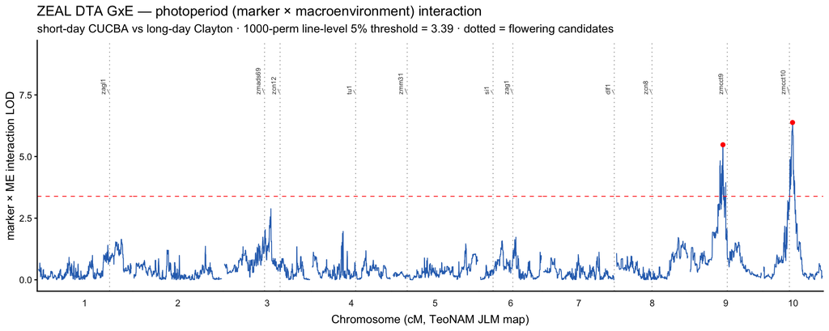

```r
if (!has_trait("dta")) {
  cat("mexg_dta_result.rds not found — run: TRAIT=DTA Rscript scripts/zeal_mexg_scan.R")
} else {
  res <- readRDS(file.path(RQ, "mexg_dta_result.rds"))
  cand <- load_cand("dta")
  print(gxe_profile(res, cand, "DTA"))
}
```

```r
if (has_trait("dta")) {
  res <- readRDS(file.path(RQ, "mexg_dta_result.rds"))
  pk <- gxe_peaks(res, load_cand("dta"))
  knitr::kable(pk, caption = sprintf(
    "DTA photoperiod (marker × ME) interaction: per-chromosome peak, %d lines, 1000-perm line-level 5%% threshold = %.2f. 'sig' = clears the interaction threshold. 1.5-LOD interval and any flowering candidate inside.",
    res$n, as.numeric(res$thr[2])
  ))
}
```

DTA photoperiod (marker × ME) interaction: per-chromosome peak, 933 lines, 1000-perm line-level 5% threshold = 3.39. ‘sig’ = clears the interaction threshold. 1.5-LOD interval and any flowering candidate inside.

| chr | pos (cM) | pos (Mb) | marker | interaction LOD | perm 5% thr | sig | 1.5-LOD CI (Mb) | candidate in CI |
| --- | --- | --- | --- | --- | --- | --- | --- | --- |
| 10 | 58.7 | 121.9 | S10_121861790 | 6.38 | 3.39 | yes | 111.7–124.9 | – |
| 9 | 67.0 | 93.6 | S9_93573588 | 5.48 | 3.39 | yes | 31.7–99.8 | – |
| 3 | 95.2 | 183.4 | S3_183440648 | 2.88 | 3.39 | no | 111.6–184.6 | zmads69 |
| 4 | 62.7 | 80.6 | S4_80598362 | 1.96 | 3.39 | no | 0.6–247.5 | tu1 |
| 6 | 73.2 | 152.3 | S6_152325251 | 1.73 | 3.39 | no | 12.3–180.6 | si1, zag1 |
| 8 | 125.9 | 176.7 | S8_176711826 | 1.72 | 3.39 | no | 0.4–182.2 | zcn8 |
| 1 | 170.0 | 299.1 | S1_299102717 | 1.64 | 3.39 | no | 0.2–308.0 | zagl1 |
| 5 | 149.3 | 219.7 | S5_219721645 | 1.46 | 3.39 | no | 0.8–225.7 | zmm31 |
| 2 | 146.1 | 227.4 | S2_227431708 | 1.36 | 3.39 | no | 0.0–242.8 | – |
| 7 | 113.4 | 174.9 | S7_174922743 | 1.12 | 3.39 | no | 0.2–185.6 | dlf1 |

## DTS GxE

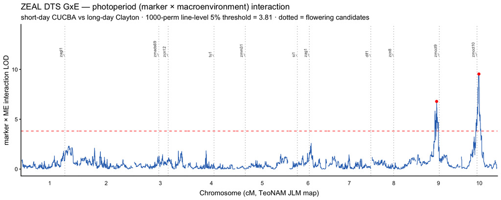

```r
if (!has_trait("dts")) {
  cat("mexg_dts_result.rds not found yet — run: TRAIT=DTS Rscript scripts/zeal_mexg_scan.R (this notebook picks it up on re-render).")
} else {
  res <- readRDS(file.path(RQ, "mexg_dts_result.rds"))
  print(gxe_profile(res, load_cand("dts"), "DTS"))
}
```

```r
if (has_trait("dts")) {
  res <- readRDS(file.path(RQ, "mexg_dts_result.rds"))
  pk <- gxe_peaks(res, load_cand("dts"))
  knitr::kable(pk, caption = sprintf(
    "DTS photoperiod (marker × ME) interaction: per-chromosome peak, %d lines, 1000-perm line-level 5%% threshold = %.2f.",
    res$n, as.numeric(res$thr[2])
  ))
}
```

DTS photoperiod (marker × ME) interaction: per-chromosome peak, 935 lines, 1000-perm line-level 5% threshold = 3.81.

| chr | pos (cM) | pos (Mb) | marker | interaction LOD | perm 5% thr | sig | 1.5-LOD CI (Mb) | candidate in CI |
| --- | --- | --- | --- | --- | --- | --- | --- | --- |
| 10 | 58.7 | 121.9 | S10_121861790 | 9.53 | 3.81 | yes | 111.7–124.9 | – |
| 9 | 66.8 | 92.5 | S9_92466088 | 6.79 | 3.81 | yes | 31.7–99.8 | – |
| 6 | 73.2 | 152.3 | S6_152325251 | 2.59 | 3.81 | no | 114.0–158.3 | zag1 |
| 1 | 160.1 | 293.3 | S1_293340555 | 2.32 | 3.81 | no | 1.0–306.5 | zagl1 |
| 2 | 50.5 | 21.4 | S2_21353658 | 2.10 | 3.81 | no | 2.3–228.6 | – |
| 4 | 61.4 | 73.3 | S4_73309023 | 1.84 | 3.81 | no | 1.8–247.5 | tu1 |
| 3 | 148.2 | 224.7 | S3_224726098 | 1.81 | 3.81 | no | 1.3–237.3 | zmads69, zcn12 |
| 5 | 149.3 | 219.7 | S5_219721645 | 1.49 | 3.81 | no | 0.8–225.7 | zmm31 |
| 7 | 71.0 | 132.1 | S7_132074599 | 1.44 | 3.81 | no | 0.2–185.6 | dlf1 |
| 8 | 0.0 | 0.4 | S8_363813 | 1.20 | 3.81 | no | 0.4–182.2 | zcn8 |

## Reading the scan

A significant **marker × ME** peak means the teosinte allele’s effect on flowering **differs between short-day (CUCBA) and long-day (Clayton)** — i.e. the locus is **photoperiod-sensitive**. These are not the same as the additive flowering QTL: a locus can have a large, consistent effect in both day lengths (strong additive, no interaction) or a modest average effect that flips sign with day length (weak additive, strong interaction). Candidate genes are marked for orientation only — a peak’s identity needs a coordinate check against the v5 annotation, not assignment by chromosome. All results are **provisional** pending real La Soledad flowering (or additional replication) and the definitive three-way sample sheet; the short-day side is currently one unreplicated environment (CUCBA).